# Animal Shelters Final Project

## Intake and Movement

I am starting by looking at the timing of intakes and outtakes during the year. I will add up the total of incomes and outcomes of each month and plot those to observe if there is any meaningful patterns.

```python
#uses austin shelter, intake and outtake amounts
#initializing each month intake and outtake amounts
jan_intake = 0
feb_intake = 0
mar_intake = 0
apr_intake = 0
may_intake = 0
jun_intake = 0
jul_intake = 0
aug_intake = 0
sep_intake = 0
oct_intake = 0
nov_intake = 0
dec_intake = 0

jan_out = 0
feb_out = 0
mar_out = 0
apr_out = 0
may_out = 0
jun_out = 0
jul_out = 0
aug_out = 0
sep_out = 0
oct_out = 0
nov_out = 0
dec_out = 0

#checks each row and adds 1 to whichever month the animal was taken in
for month in austin_shelter["intake_month"]:
    if month ==  1:
        jan_intake += 1
    elif month ==  2:
        feb_intake += 1
    elif month ==  3:
        mar_intake += 1
    elif month ==  4:
        apr_intake += 1
    elif month ==  5:
        may_intake += 1
    elif month ==  6:
        jun_intake += 1
    elif month ==  7:
        jul_intake += 1
    elif month ==  8:
        aug_intake += 1
    elif month ==  9:
        sep_intake += 1
    elif month ==  10:
        oct_intake += 1
    elif month ==  11:
        nov_intake += 1
    elif month ==  12:
        dec_intake += 1

#checks each row and adds 1 to whichever month the animal was moved out
for month in austin_shelter["outcome_month"]:
    if month ==  1:
        jan_out += 1
    elif month ==  2:
        feb_out += 1
    elif month ==  3:
        mar_out += 1
    elif month ==  4:
        apr_out += 1
    elif month ==  5:
        may_out += 1
    elif month ==  6:
        jun_out += 1
    elif month ==  7:
        jul_out += 1
    elif month ==  8:
        aug_out += 1
    elif month ==  9:
        sep_out += 1
    elif month ==  10:
        oct_out += 1
    elif month ==  11:
        nov_out += 1
    elif month ==  12:
        dec_out += 1

#creates categories to be plotted later
months = ["Jan", "Feb", "Mar", "Apr", "May", "Jun", "Jul", "Aug", "Sep", "Oct", "Nov", "Dec"]
month_intake_amt_austin = [jan_intake,feb_intake,mar_intake,apr_intake,may_intake,jun_intake,jul_intake,aug_intake,sep_intake,oct_intake,nov_intake,dec_intake]
month_out_amt_austin = [jan_out,feb_out,mar_out,apr_out,may_out,jun_out,jul_out,aug_out,sep_out,oct_out,nov_out,dec_out]
```

```python
#make major classes - Austin
#Disease or injury - 'Wildlife'
#"Lifestyle of owner - 'Owner Surrender
#behavior -  'Public Assist'
# abuse - 'Euthanasia Request'
#abandoned or stray - "Stray"

sick_or_injured = 0
lifestyle_change = 0
behavior = 0
abuse = 0
abandoned = 0
other = 0

#checks the reason for intake and adds 1 to the correct category
for reason in austin_shelter["intake_type"]:
    if reason == 'Wildlife':
        sick_or_injured += 1
    elif reason == 'Owner Surrender':
        lifestyle_change += 1
    elif reason == 'Public Assist':
        behavior += 1
    elif reason == 'Euthanasia Request':
        abuse += 1
    elif reason == "Stray":
        abandoned += 1
    else:
        other += 1

intake_amounts_austin = [sick_or_injured, lifestyle_change, behavior, abuse, abandoned, other]
intake_reasons_austin = ["Sick/Injured", "Lifestyle Change", "Behavior", "Abuse", "Abandoned", "Other"]
```

```python
#unique Bloomington Intake reasons
shelters["intakereason"].unique()
```

```
array(['Moving', 'Abandoned', 'Incompatible with owner lifestyle',
       'Rabies Monitoring', 'Marriage/Relationship split',
       'Owner Deceased', 'Stray', nan, 'Police Assist', 'Biting',
       'Owner Died', 'TNR - Trap/Neuter/Release', 'Unable to Afford',
       'Unsuitable Accommodation', 'Injured Wildlife', 'Allergies',
       'Transfer from Other Shelter', 'Born in Shelter', 'Sick/Injured',
       'Landlord issues', 'Litter relinquishment',
       'Owner requested Euthanasia', 'Abuse/ neglect',
       'Incompatible with other pets', 'Behavioral Issues', 'DOA'],
      dtype=object)
```

```python
#unique Austin Intake reasons
austin_shelter['intake_type'].unique()
```

```
array(['Stray', 'Public Assist', 'Owner Surrender', 'Euthanasia Request',
       'Wildlife'], dtype=object)
```

```python
#make major classes - Bloomington
#Disease or injury - "Rabies Monitoring", "Injured Wildlife"
#"Lifestyle of owner - "Incompatible with owner lifestyle", "Marriage/Relationship split", "Unsuitable Accommodation","Unable to Afford",
    #"Landlord issues", "Incompatible with other pets", "Moving" , "Litter relinquishment"
#already in shelter - "Transfer from Other Shelter", "Born in Shelter"
#behavior -  "Biting", "Behavioral Issues"
# abuse - "Abuse/ neglect", "Owner requested Euthanasia", "Police Assist"
#abandoned or stray - "Abandoned", "Stray"
#owner death -  "Owner Deceased", "Owner Died"

sick_or_injured = 0
lifestyle_change = 0
in_shelter = 0
behavior = 0
abuse = 0
abandoned = 0
other = 0
owner_death = 0
TNR = 0

#checks the reason for intake and adds 1 to the correct category
for reason in shelters["intakereason"]:
    if reason == "Rabies Monitoring" or reason == "Injured Wildlife":
        sick_or_injured += 1
    elif reason == "Incompatible with owner lifestyle" or reason == "Marriage/Relationship split" or reason == "Unsuitable Accommodation" or reason == "Unable to Afford" or reason == "Landlord issues" or reason == "Incompatible with other pets" or reason == "Moving" or reason == "Litter relinquishment":
        lifestyle_change += 1
    elif reason == "Transfer from Other Shelter" or reason == "Born in Shelter":
        in_shelter += 1
    elif reason == "Biting" or reason == "Behavioral Issues":
        behavior += 1
    elif reason == "Abuse/ neglect" or reason == "Owner requested Euthanasia" or reason == "Police Assist":
        abuse += 1
    elif reason == "Abandoned" or reason == "Stray":
        abandoned += 1
    elif reason ==  "Owner Deceased" or reason == "Owner Died":
        owner_death += 1
    elif reason == 'TNR - Trap/Neuter/Release':
        TNR += 1
    else:
        other += 1

intake_amounts_bloom = [sick_or_injured, lifestyle_change, in_shelter, behavior, abuse, abandoned, owner_death, TNR, other]
intake_reasons_bloom = ["Sick/Injured", "Lifestyle Change", "In Shelter", "Behavior", "Abuse", "Abandoned", "Owner Death", "TNR", "Other"]
```

```python
#unique Bloomington movement types
shelters["movementtype"].unique()
```

```
array(['Adoption', 'Foster', 'Transfer', 'Reclaimed', 'Released To Wild',
       'Stolen', 'Escaped'], dtype=object)
```

```python
#classes for Bloomington movement
adopted = 0
foster = 0
transfer = 0
reclaimed = 0
other = 0

#checks the reason for movement and adds 1 to the correct category
for type in shelters["movementtype"]:
    if type == "Adoption":
        adopted += 1
    elif type == "Foster":
        foster += 1
    elif type == "Transfer":
        transfer += 1
    elif type == "Reclaimed":
        reclaimed += 1
    elif type == "Released To Wild" or type == "Stolen" or type == "Escaped":
        other += 1


movement_amounts_bloom = [adopted, foster, transfer, reclaimed, other]
movement_reasons_bloom = ["Adopted", "Foster", "Transfer", "Reclaimed", "Other"]
```

## Age

```python
#function that takes in a dataframe, the range of years wanted, and which column will contain the ages in years
def age_pets(petdf, years_min, years_max, col_name):
    lower_mask = petdf[col_name] >= years_min
    upper_mask = petdf[col_name] < years_max
    lower = petdf[lower_mask]
    upper_mask = upper_mask.reindex(lower.index)
    upper = lower[upper_mask]
    return upper
```

```python
#austin shelter - changing the age column from months to years for easier comprehension
age_years = []
#converts age from year/month to just years
for time in austin_shelter["age_upon_outcome"]:
    if 'year' in time:
        years = time.split(' year')[0] #splits the age at the word years and keeps just the first number to assign age in years
        years = int(years)
    else:
        years = 0
    age_years.append(years)
austin_shelter["Years Age"] = age_years #makes a new column that marks the age in years
austin_shelter
```

|  | age_upon_outcome | outcome_type | age_upon_outcome_(years) | outcome_month | animal_type | breed | color | intake_type | sex_upon_intake | intake_month | time_in_shelter | time_in_shelter_days | Years Age |
| --- | --- | --- | --- | --- | --- | --- | --- | --- | --- | --- | --- | --- | --- |
| 0 | 10 years | Return to Owner | 10.000000 | 12 | Dog | Spinone Italiano Mix | Yellow/White | Stray | Neutered Male | 12 | 0 days 14:07:00.000000000 | 0.588194 | 10 |
| 1 | 7 years | Return to Owner | 7.000000 | 12 | Dog | Spinone Italiano Mix | Yellow/White | Public Assist | Neutered Male | 12 | 1 days 06:14:00.000000000 | 1.259722 | 7 |
| 2 | 6 years | Return to Owner | 6.000000 | 3 | Dog | Spinone Italiano Mix | Yellow/White | Public Assist | Neutered Male | 3 | 1 days 02:44:00.000000000 | 1.113889 | 6 |
| 3 | 10 years | Transfer | 10.000000 | 4 | Dog | Dachshund | Tricolor | Owner Surrender | Neutered Male | 4 | 4 days 23:17:00.000000000 | 4.970139 | 10 |
| 4 | 16 years | Return to Owner | 16.000000 | 11 | Dog | Shetland Sheepdog | Brown/White | Public Assist | Neutered Male | 11 | 0 days 02:52:00.000000000 | 0.119444 | 16 |
| ... | ... | ... | ... | ... | ... | ... | ... | ... | ... | ... | ... | ... | ... |
| 79667 | 2 weeks | Transfer | 0.038356 | 3 | Cat | Domestic Shorthair Mix | Tortie | Stray | Unknown | 3 | 0 days 01:51:00.000000000 | 0.077083 | 0 |
| 79668 | 2 years | Euthanasia | 2.000000 | 3 | Other | Bat Mix | Brown | Wildlife | Unknown | 3 | 0 days 01:17:00.000000000 | 0.053472 | 2 |
| 79669 | 1 year | Euthanasia | 1.000000 | 3 | Other | Bat Mix | Brown | Wildlife | Unknown | 3 | 0 days 01:09:00.000000000 | 0.047917 | 1 |
| 79670 | 10 months | Return to Owner | 0.821918 | 3 | Dog | Labrador Retriever Mix | Black/White | Stray | Intact Male | 3 | 1 days 18:18:00.000000000 | 1.762500 | 0 |
| 79671 | 10 years | Euthanasia | 10.000000 | 3 | Dog | Boxer Mix | Brown Brindle | Stray | Spayed Female | 3 | 0 days 19:32:00.000000000 | 0.813889 | 10 |

79672 rows × 13 columns

```python
#creates a new DataFrame with just dogs
dogs_only_austin_mask = austin_shelter["animal_type"] == "Dog"
dogs_only_austin = austin_shelter[dogs_only_austin_mask]
```

```python
#austin shelter - creating puppy, middle age, and old dog categories
puppy_austin = age_pets(dogs_only_austin, 0, 1, "Years Age")
mid_age_austin = age_pets(dogs_only_austin, 1, 10, "Years Age")
old_austin = age_pets(dogs_only_austin, 10, 26, "Years Age")

puppy_time_total_austin = 0
mid_age_time_total_austin = 0
old_time_total_austin = 0

#adds up the total amount of days the dogs in each class spent
for time in puppy_austin["time_in_shelter_days"]:
    puppy_time_total_austin += time
for time in mid_age_austin["time_in_shelter_days"]:
    mid_age_time_total_austin += time
for time in old_austin["time_in_shelter_days"]:
   old_time_total_austin += time

#finds the average time spent by each class
puppy_time_avg_austin = puppy_time_total_austin / len(puppy_austin["time_in_shelter_days"])
mid_age_time_avg_austin = mid_age_time_total_austin / len(mid_age_austin["time_in_shelter_days"])
old_time_avg_austin = old_time_total_austin / len(old_austin["time_in_shelter_days"])

age_times_austin = [puppy_time_avg_austin, mid_age_time_avg_austin, old_time_avg_austin]
age_classes = ["Puppies", "Middle Age", "Seniors"]

age_amounts_austin = [len(puppy_austin["Years Age"]), len(mid_age_austin["Years Age"]), len(old_austin["Years Age"])]
```

```python
#bloomington ages
shelters["animalage"]
years_age = []
for age in shelters["animalage"]:
    if "years" in age:
        years = age.split(' years')[0]
        years = int(years)
        years_age.append(years)
    else:
        years = 0
        years = int(years)
        years_age.append(years)

shelters["Years Age"] = years_age
dogs_only_mask_bloom = shelters["speciesname"] == "Dog"
dogs_only_bloom = shelters[dogs_only_mask_bloom]
```

```python
#bloomington age amounts
puppies_bloom = age_pets(dogs_only_bloom, 0, 1, "Years Age")
dogs_middle_age_bloom = age_pets(dogs_only_bloom, 1, 10, "Years Age")
senior_dogs_bloom = age_pets(dogs_only_bloom, 10, 20, "Years Age")

age_amounts_bloom = [len(puppies_bloom["Years Age"]), len(dogs_middle_age_bloom["Years Age"]), len(senior_dogs_bloom["Years Age"])]
```

## Breed

```python
#Austin breeds
breeds_austin = austin_shelter["breed"]
unique_breeds = []
for breed in breeds_austin:
    if '/' in breed:
        breed = breed.split('/')[0]  #splits mixed breeds and assigns it to its primary/first breed
    if breed not in unique_breeds:
        unique_breeds.append(breed)
#creates a dictionary containing breed name, the total amount of that breed, the amount spent by all members of the breed, and the avg time
#German Shepherd, Pitbull, Lab, Golden, Husky, Hound, Chihuahua, Terrier, Australian Shepherd, Border Collie, Shih Tzu, Saint Bernard, Beagle, Pug,
# Dachshund, Spaniel, Rottweiler, Poodle, Corgi, Great Dane
breed_dict = {
    "German Shepherd" : {"Count": 0, "TotalTime": 0 , "AvgTime": 0},
    "Pit Bull" : {"Count": 0, "TotalTime": 0 , "AvgTime": 0},
    "Lab" : {"Count": 0, "TotalTime": 0 , "AvgTime": 0},
    "Golden Retriever" : {"Count": 0, "TotalTime": 0 , "AvgTime": 0},
    "Husky": {"Count": 0, "TotalTime": 0 , "AvgTime": 0},
    "Hound": {"Count": 0, "TotalTime": 0 , "AvgTime": 0},
    "Chihuahua": {"Count": 0, "TotalTime": 0 , "AvgTime": 0},
    "Terrier": {"Count": 0, "TotalTime": 0 , "AvgTime": 0},
    "Australian Shepherd": {"Count": 0, "TotalTime": 0 , "AvgTime": 0},
    "Collie": {"Count": 0, "TotalTime": 0 , "AvgTime": 0},
    "Shih Tzu": {"Count": 0, "TotalTime": 0 , "AvgTime": 0},
    "Saint Bernard": {"Count": 0, "TotalTime": 0 , "AvgTime": 0},
    "Beagle": {"Count": 0, "TotalTime": 0 , "AvgTime": 0},
    "Pug": {"Count": 0, "TotalTime": 0 , "AvgTime": 0},
    "Dachshund": {"Count": 0, "TotalTime": 0 , "AvgTime": 0},
    "Spaniel": {"Count": 0, "TotalTime": 0 , "AvgTime": 0},
    "Rottweiler": {"Count": 0, "TotalTime": 0 , "AvgTime": 0},
    "Poodle": {"Count": 0, "TotalTime": 0 , "AvgTime": 0},
    "Corgi": {"Count": 0, "TotalTime": 0 , "AvgTime": 0},
    "Great Dane": {"Count": 0, "TotalTime": 0 , "AvgTime": 0}
}

#finds all members of each breed and caluclates the total amount of time spent for each one
for index in range(len(breeds_austin)):
    if "German" in breeds_austin[index]:
        breed_dict["German Shepherd"]["Count"] += 1
        breed_dict["German Shepherd"]["TotalTime"] += austin_shelter["time_in_shelter_days"][index]
    elif "Pit" in breeds_austin[index]:
        breed_dict["Pit Bull"]["Count"] += 1
        breed_dict["Pit Bull"]["TotalTime"] += austin_shelter["time_in_shelter_days"][index]
    elif "Lab" in breeds_austin[index]:
        breed_dict["Lab"]["Count"] += 1
        breed_dict["Lab"]["TotalTime"] += austin_shelter["time_in_shelter_days"][index]
    elif "Golden" in breeds_austin[index]:
        breed_dict["Golden Retriever"]["Count"] += 1
        breed_dict["Golden Retriever"]["TotalTime"] += austin_shelter["time_in_shelter_days"][index]
    elif "Husky" in breeds_austin[index]:
        breed_dict["Husky"]["Count"] += 1
        breed_dict["Husky"]["TotalTime"] += austin_shelter["time_in_shelter_days"][index]
    elif "Hound" in breeds_austin[index] or "hound" in breeds_austin[index]:
        breed_dict["Hound"]["Count"] += 1
        breed_dict["Hound"]["TotalTime"] += austin_shelter["time_in_shelter_days"][index]
    elif "Chihuahua" in breeds_austin[index]:
        breed_dict["Chihuahua"]["Count"] += 1
        breed_dict["Chihuahua"]["TotalTime"] += austin_shelter["time_in_shelter_days"][index]
    elif "Terrier" in breeds_austin[index]:
        breed_dict["Terrier"]["Count"] += 1
        breed_dict["Terrier"]["TotalTime"] += austin_shelter["time_in_shelter_days"][index]
    elif "Australian" in breeds_austin[index]:
        breed_dict["Australian Shepherd"]["Count"] += 1
        breed_dict["Australian Shepherd"]["TotalTime"] += austin_shelter["time_in_shelter_days"][index]
    elif "Collie" in breeds_austin[index]:
        breed_dict["Collie"]["Count"] += 1
        breed_dict["Collie"]["TotalTime"] += austin_shelter["time_in_shelter_days"][index]
    elif "Shih" in breeds_austin[index]:
        breed_dict["Shih Tzu"]["Count"] += 1
        breed_dict["Shih Tzu"]["TotalTime"] += austin_shelter["time_in_shelter_days"][index]
    elif "Bernard" in breeds_austin[index]:
        breed_dict["Saint Bernard"]["Count"] += 1
        breed_dict["Saint Bernard"]["TotalTime"] += austin_shelter["time_in_shelter_days"][index]
    elif "Beagle" in breeds_austin[index]:
        breed_dict["Beagle"]["Count"] += 1
        breed_dict["Beagle"]["TotalTime"] += austin_shelter["time_in_shelter_days"][index]
    elif "Pug" in breeds_austin[index]:
        breed_dict["Pug"]["Count"] += 1
        breed_dict["Pug"]["TotalTime"] += austin_shelter["time_in_shelter_days"][index]
    elif "Dachshund" in breeds_austin[index]:
        breed_dict["Dachshund"]["Count"] += 1
        breed_dict["Dachshund"]["TotalTime"] += austin_shelter["time_in_shelter_days"][index]
    elif "Spaniel" in breeds_austin[index]:
        breed_dict["Spaniel"]["Count"] += 1
        breed_dict["Spaniel"]["TotalTime"] += austin_shelter["time_in_shelter_days"][index]
    elif "Rottweiler" in breeds_austin[index]:
        breed_dict["Rottweiler"]["Count"] += 1
        breed_dict["Rottweiler"]["TotalTime"] += austin_shelter["time_in_shelter_days"][index]
    elif "Poodle" in breeds_austin[index]:
        breed_dict["Poodle"]["Count"] += 1
        breed_dict["Poodle"]["TotalTime"] += austin_shelter["time_in_shelter_days"][index]
    elif "Corgi" in breeds_austin[index]:
        breed_dict["Corgi"]["Count"] += 1
        breed_dict["Corgi"]["TotalTime"] += austin_shelter["time_in_shelter_days"][index]
    elif "Dane" in breeds_austin[index]:
        breed_dict["Great Dane"]["Count"] += 1
        breed_dict["Great Dane"]["TotalTime"] += austin_shelter["time_in_shelter_days"][index]

# Averages
averages_austin = []
austin_breed_counts = []
#finds the average time for each breed
for breed in breed_dict:
    avg_time = breed_dict[breed]["TotalTime"] / breed_dict[breed]["Count"]
    averages_austin.append(avg_time)
    count = breed_dict[breed]["Count"]
    austin_breed_counts.append(count)

breed_times_austin = averages_austin
breed_names = ["German Shepherd", "Pit Bull", "Lab", "Golden Retriever", "Husky", "Hound", "Chihuahua", "Terrier", "Australian Shepherd", "Collie", "Shih Tzu", "Saint Bernard", "Beagle", "Pug", "Dachshund", "Spaniel", "Rottweiler", "Poodle", "Corgi", "Great Dane"]
breed_amounts_austin = austin_breed_counts
```

```python
#bloomington drop all nan values in breedname
breeds_only = shelters["breedname"]
breeds_only.dropna(inplace=True)
```

```python
breed_types = breeds_only.unique()
```

```python
new_breeds = []
for breed in breed_types:
    if '/' in breed:
        breed = breed.split('/')[0]
    if breed not in new_breeds:
        new_breeds.append(breed)

new_breeds
#German Shepherd, Pitbull, Lab, Golden, Husky, Hound, Chihuahua, Terrier, Australian Shepherd, Border Collie, Shih Tzu, Saint Bernard, Beagle, Pug,
# Dachshund, Spaniel, Rottweiler, Poodle, Corgi, Great Dane
german_shep = 0
pit = 0
lab = 0
golden = 0
husky = 0
hound = 0
chihuahua = 0
terrier = 0
australian_shep = 0
collie = 0
shih_tzu = 0
saint_bernard = 0
beagle = 0
pug = 0
dachshund = 0
spaniel = 0
rottie = 0
poodle = 0
corgi = 0
great_dane = 0


for breed in breeds_only:
    if "German" in breed:
        german_shep += 1
    elif "Pit" in breed:
        pit += 1
    elif "Lab" in breed:
        lab += 1
    elif "Golden" in breed:
        golden += 1
    elif "Husky" in breed:
        husky += 1
    elif "Hound" in breed or "hound" in breed:
        hound += 1
    elif "Chihuahua" in breed:
        chihuahua += 1
    elif "Terrier" in breed:
        terrier += 1
    elif "Australian" in breed:
        australian_shep += 1
    elif "Collie" in breed:
        collie += 1
    elif "Shih" in breed:
        shih_tzu += 1
    elif "Bernard" in breed:
        saint_bernard += 1
    elif "Beagle" in breed:
        beagle += 1
    elif "Pug" in breed:
        pug += 1
    elif "Dachshund" in breed:
        dachshund += 1
    elif "Spaniel" in breed:
        spaniel += 1
    elif "Rottweiler" in breed:
        rottie += 1
    elif "Poodle" in breed:
        poodle += 1
    elif "Corgi" in breed:
        corgi += 1
    elif "Dane" in breed:
        great_dane += 1

breed_amounts = [german_shep, pit, lab, golden, husky, hound, chihuahua, terrier, australian_shep, collie, shih_tzu, saint_bernard, beagle, pug, dachshund, spaniel, rottie, poodle, corgi, great_dane]
```

## Results

```python
colors = ["lightskyblue", 'paleturquoise', 'aquamarine', 'palegreen']
```

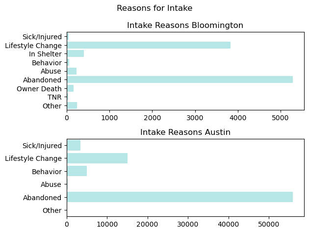

```python
plt.suptitle("Reasons for Intake")
#bloom
plt.subplot(2,1,1)
sns.barplot(x=intake_amounts_bloom, y=intake_reasons_bloom, orient="y", color=colors[1])
plt.title("Intake Reasons Bloomington")
#austin
plt.subplot(2,1,2)
sns.barplot(x=intake_amounts_austin, y=intake_reasons_austin, orient="y", color=colors[1])
plt.title("Intake Reasons Austin")
plt.tight_layout()
```

Most animals come to the shelters as strays or because they were abandoned. Second most common is a lifestyle change which could be for a variety of reasons including the death of the owner, moving or new housing, relationship split, unable to afford care, or litter relinquishment.

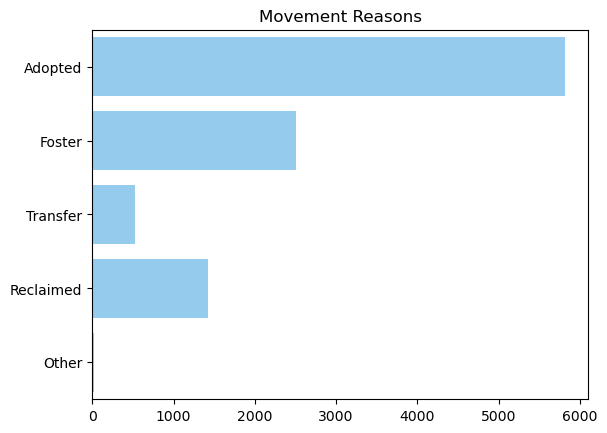

```python
sns.barplot(x=movement_amounts_bloom, y=movement_reasons_bloom, orient="y", color=colors[0])
plt.title("Movement Reasons")
```

Most animals leave the shelter because they are adopted or less likely, fostered.

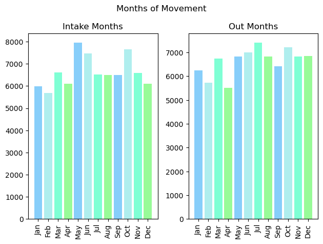

```python
plt.suptitle("Months of Movement")
plt.subplot(1,2,1)
plt.bar(months,month_intake_amt_austin, color=colors)
plt.title("Intake Months")
plt.xticks(rotation=90)
plt.subplot(1,2,2)
plt.bar(months,month_out_amt_austin, color=colors)
plt.title("Out Months")
plt.xticks(rotation=90)
plt.tight_layout()
```

There appears to be a spike in animals taken into the shelter in May, June, and October and a very slight spike in adoptions/movements out of the shelter in July.

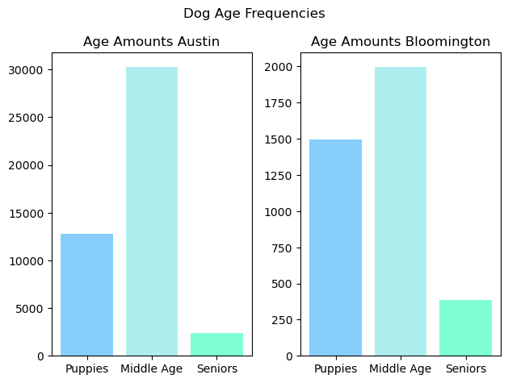

```python
plt.suptitle("Dog Age Frequencies")
plt.subplot(1,2,1)
plt.bar(age_classes, age_amounts_austin, color=colors)
plt.title("Age Amounts Austin")
plt.subplot(1,2,2)
plt.bar(age_classes, age_amounts_bloom, color=colors)
plt.title("Age Amounts Bloomington")
plt.tight_layout()
```

Seniors consistently make up the least of the population in both shelters and middle aged dogs between 1 and 9 make up the most. The population consisting of puppies varies more but still make up a semi large portion of the population.

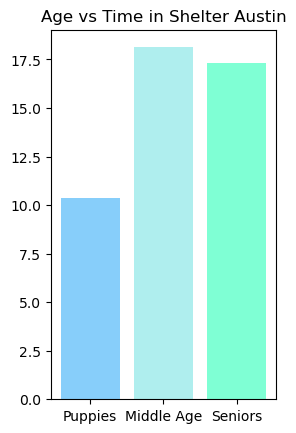

```python
plt.subplot(1,2,1)
plt.bar(age_classes, age_times_austin, color=colors)
plt.title("Age vs Time in Shelter Austin")
```

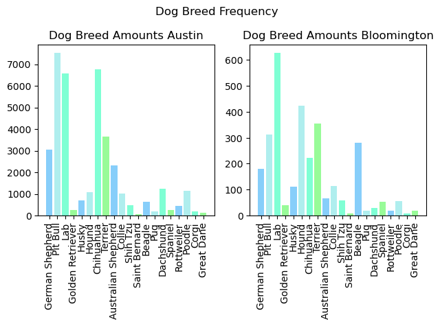

```python
plt.suptitle("Dog Breed Frequency")
plt.subplot(1,2,1)
plt.bar(breed_names, breed_amounts_austin, color=colors)
plt.xticks(rotation=90)
plt.title("Dog Breed Amounts Austin")
plt.subplot(1,2,2)
plt.bar(breed_names, breed_amounts, color=colors)
plt.xticks(rotation=90)
plt.title("Dog Breed Amounts Bloomington")
plt.tight_layout()
```

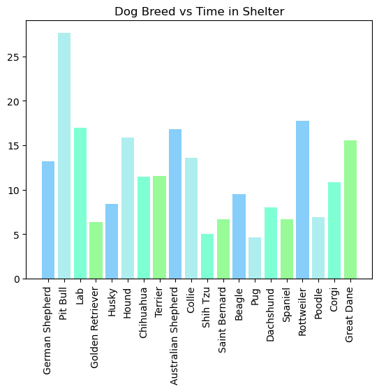

```python
plt.bar(breed_names, breed_times_austin, color=colors)
plt.xticks(rotation=90)
plt.title("Dog Breed vs Time in Shelter")
```

Pit bulls and rottweilers appear to spend the longest in the shelter in Austin which aligns with stereotypes associated with each breed. Pit bulls and rottweilers are bigger dogs and are paired with the idea of violence and aggression which could be contributing to the length of time they spend in the shelter.

## Discussion and Conclusion

I would make a few changes to how I went about this analysis of shelters. First, I would do a more thorough check of my data, ensuring it is credible, reliable, and has all the information I would need to answer my research questions. I would also be more careful on my sample sizes and comparing shelters that are very different in capacity. Second, I would try to dig slightly deeper when trying to analyze the trends between certain demographics and how long they spend in the shelter or their frequencies. Finally, if I had more time, I would optimize my code more and utilize more functions. I used functions occassionally but if I had more time, I would go back and make a lot of the repeated code into functions to make the code easier to understand.

## References

Moulton, Carol, et al. “PDF.” AVMA Publications, 1 Apr. 1991.

Schlegel, Aaron. “Austin Animal Center Shelter Intakes and Outcomes.” Kaggle, 9 Apr. 2018, www.kaggle.com/datasets/aaronschlegel/austin- animal-center-shelter-intakes-and-outcomes?select=aac_intakes_outcomes.csv.

Jin, Bonnie. “Animal Care and Control Adopted Animals.” Kaggle, 2 Nov. 2020, www.kaggle.com/datasets/jinbonnie/animal-data.